# pA-DamID LAD enrichment

Tom van Schaik

2019-07-29

### Introduction

I have sequenced various pA-DamID experiments for which I also have microscopy data. Using the images, I determine the LAD enrichment for a number of cells hoping that these numbers reflect the LAD enrichment / dynamic range / signal-to-noise of the sequencing data. In other words, I hope to be able to optimize pA-DamID with microscopy output.

The question though, does this work? Here, I will determine the LAD enrichment for the various experiments and later compare these numbers with the microscopy output.

### Method

I have already defined LADs of Hap1 cells. I will simply count reads in the LADs and determine the overall log2 enrichment.

### Functions

Supporting functions.

```r
ReadExperiments <- function(experiments, experiments_dir) {
  # Create one GRanges objects from all the experiments

  # Create an empty GRanges
  gr <- import.bed(file.path(experiments_dir, experiments[1]))
  mcols(gr) <- NULL

  # For every experiment, add a GRanges column
  for (exp in experiments) {
    exp_values <- read.table(file.path(experiments_dir, exp), sep = "\t")[, 4]
    mcols(gr) <- cbind(mcols(gr), exp_values)
  }

  # Rename the columns
  names(mcols(gr)) <- gsub("-20kb.*", "", experiments)

  gr
}

CalculateEnrichment <- function(data, LADs) {
  # For a each column in a (gr) data object, calculate the LAD enrichment

  # Find the overlap
  lad.idx <- overlapsAny(data, LADs[which(mcols(LADs)$name == "AD")])
  ilad.idx <- overlapsAny(data, LADs[which(mcols(LADs)$name == "iAD")])

  # Determine the sums
  lad.sums <- colSums(as(mcols(data), "data.frame")[lad.idx, ])
  ilad.sums <- colSums(as(mcols(data), "data.frame")[ilad.idx, ])

  # Calculate the ratios
  lad_enrichment <- data.frame(lad = lad.sums,
                               ilad = ilad.sums,
                               ratio = log2(lad.sums / ilad.sums))

  lad_enrichment$samples <- row.names(lad_enrichment)

  lad_enrichment

}
```

### Set-up

Set the parameters and list the data.

```r
# Load dependencies
suppressPackageStartupMessages(library(GenomicRanges))
suppressPackageStartupMessages(library(rtracklayer))
suppressPackageStartupMessages(library(ggplot2))
suppressPackageStartupMessages(library(reshape2))
suppressPackageStartupMessages(library(ggbeeswarm))
suppressPackageStartupMessages(library(RColorBrewer))


# Load the LADs
Hap1_LADs <- import.bed("~/mydata/proj/3D_nucleus/results/ts180110_4DN_DataProcessing/results/HMM/bin-20kb/Hap1_LMNB1-20kb-combined_HMM.txt.gz")

# List the pA-DamID experiments
experiments_dir <- c("results/counts/bin-20kb/")
experiments <- list.files(experiments_dir, pattern = "Hap1")

# Read all pA-DamID files
data <- ReadExperiments(experiments, experiments_dir)

# Note: also add the DamID data sets
data_damid <- ReadExperiments(experiments = c("Hap1_r1_Dam10_1-20kb.counts.txt.gz",
                                              "Hap1_r1_LMNB1-20kb.counts.txt.gz",
                                              "Hap1_r2_Dam10-20kb.counts.txt.gz",
                                              "Hap1_r2_LMNB1-20kb.counts.txt.gz"),
                              experiments_dir = "~/mydata/proj/3D_nucleus/results/ts180110_4DN_DataProcessing/results/counts/bin-20kb/")
```

### Calculate the LAD enrichment

Index based on LAD overlap and determine the colSums.

```r
# Calculate the enrichment
lad_enrichment <- CalculateEnrichment(data, Hap1_LADs)
lad_enrichment_damid <- CalculateEnrichment(data_damid, Hap1_LADs)
```

### Plot this

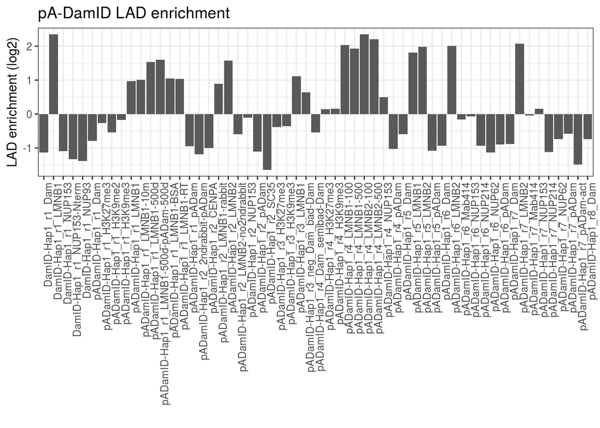

```r
ggplot(lad_enrichment, aes(x = samples, y = ratio)) +
  geom_bar(stat = "identity") +
  xlab("") +
  ylab("LAD enrichment (log2)") +
  ggtitle("pA-DamID LAD enrichment") +
  theme_bw() +
  theme(axis.text.x = element_text(angle = 90, hjust = 1))
```

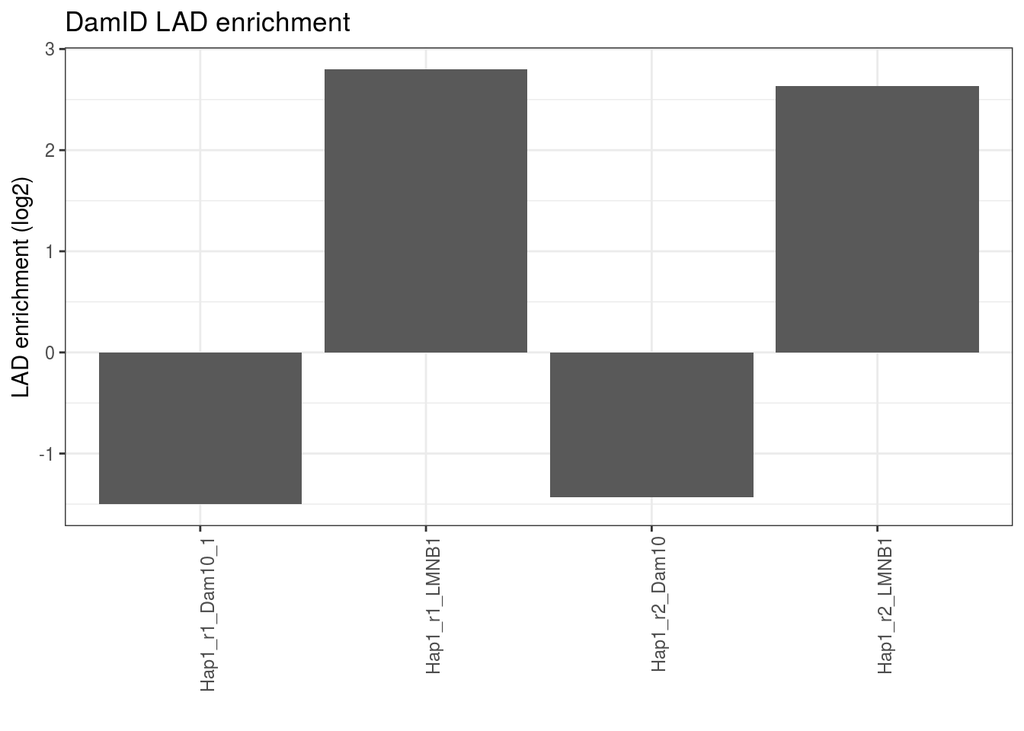

```r
ggplot(lad_enrichment_damid, aes(x = samples, y = ratio)) +
  geom_bar(stat = "identity") +
  xlab("") +
  ylab("LAD enrichment (log2)") +
  ggtitle("DamID LAD enrichment") +
  theme_bw() +
  theme(axis.text.x = element_text(angle = 90, hjust = 1))
```

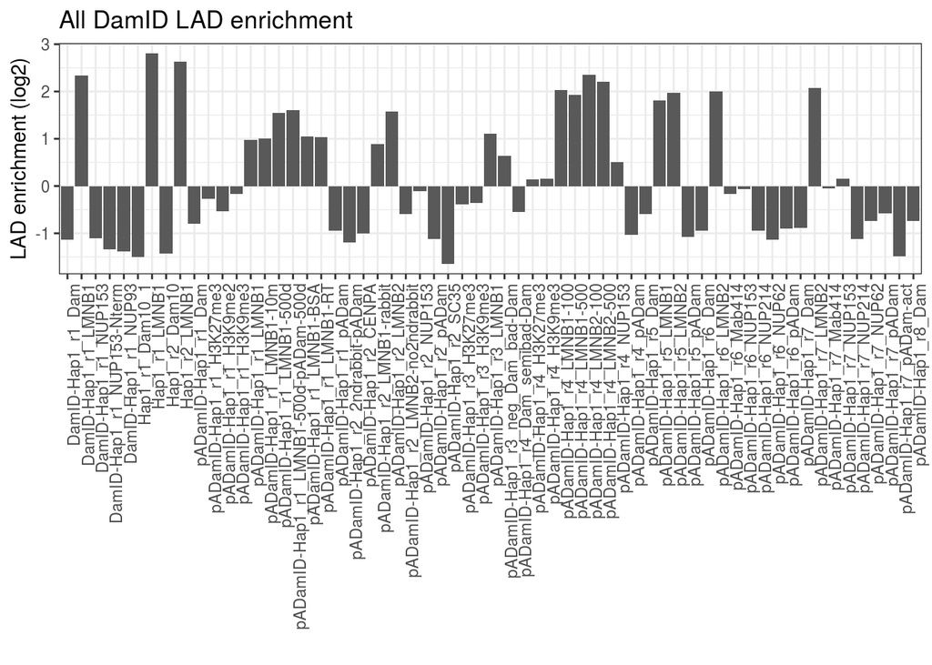

```r
ggplot(rbind(lad_enrichment, lad_enrichment_damid),
       aes(x = samples, y = ratio)) +
  geom_bar(stat = "identity") +
  xlab("") +
  ylab("LAD enrichment (log2)") +
  ggtitle("All DamID LAD enrichment") +
  theme_bw() +
  theme(axis.text.x = element_text(angle = 90, hjust = 1))
```

It seems that I am indeed getting different LAD enrichments. I should write down these numbers and compare them with the microscopy numbers. Also note that the values are not the same as the regular DamID values.

```r
output_dir <- "ts190729_LADenrichment"
dir.create(output_dir, showWarnings = FALSE)
write.table(lad_enrichment, file.path(output_dir,
                                      "lad_enrichment.txt"),
            sep = "\t", col.names = T, row.names = F, quote = F)
```